# 산업공학특론I_13-14주차_산업데이터분석

2024-05-29

## [데이터 분석 개요]

### 1. 대상 데이터: 다단계 공정 데이터셋

(https://www.kaggle.com/datasets/supergus/multistage-continuousflow-manufacturing-process)

미시간 주 디트로이트 근처의 실제 생산 라인 내에서 여러 위치, 여러 생산 라인에 대하여 계측한 데이터

다양한 입력 데이터로부터 라인의 출력 특정 속성을 예측하기 위한 목적으로 수집

해당 공정 라인은 병렬 및 직렬 단계로 구성된 고속 연속 제조 공정으로, 다음과 같은 구조를 가짐

- Stage 1에서는 M1, M2, M3 기계가 병렬로 작동하며, 이들의 출력이 결합기로 전달
- 결합기에서 출력되는 Stage 1에 대한 예측치는 제작된 제품의 외부 표면을 둘러싼 15개의 위치에서 측정
- 다음으로, M4와 M5가 직렬로 처리하는 Stage 2로 이동
- M5 작동 후에는 동일한 15개의 위치에 대한 Stage 2의 측정이 이루어짐

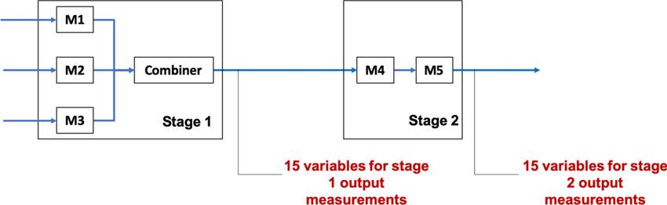

* Oleghe, O. (2020). A predictive noise correction methodology for manufacturing process datasets. Journal of Big Data, 7(1), 89.

### 2. 분석 절차

데이터 탐색 및 전처리 / 특징 추출 및 차원 축소 / 모델 학습 및 평가 순서로 3단계로 나누어 분석 진행

2단계 공정인 관계로 Stage 1에 대한 예측모델, Stage 2에 대한 예측모델을 2단계로 모델링할 것 (이 때, Stage 2의 결과는 Stage 1에 영향을 받음)

원래 Stage 1, Stage 2에 대한 예측값은 각각 15개씩이지만, 본 강의에서는 다변량 예측을 다루지 않는 관계로 각 Stage에 대한 평균값을 종속변수로 설정

팀별로 작업을 수행하며, 작업 코드는 팀장의 Github에 Push하여 공유, 통찰력 있는 분석 기법 발굴 시 모두와 공유

가이드로 제공된 참고문헌을 바탕으로 다양한 방법론으로 분석을 수행

## [데이터 분석]

### 1. 데이터 탐색 및 전처리

- 데이터의 전반적인 분포, 특징을 파악하기 위한 기초 분석 진행
- 다양한 전처리 방법론을 활용하여 데이터를 정제 (e.g. 필요없는 변수 및 이상치/노이즈 제거 또는 보정, 표준화 등)
- 데이터 전처리 순서 (학습, 테스트셋 분할 전후)를 꼼꼼히 살펴보고 진행할 것

```r
dat <- read.csv('산업공학특론I_13-14주차_데이터.csv')

# timestamp 변수 삭제
dat <- dat[,-1]

# unique값 적은 변수 살펴보기
uniqval <- function(x){length(unique(x))}
dat_uniq <- apply(dat,2,uniqval)
apply(dat[,dat_uniq<10], 2, unique)
```

```
## $Machine1.RawMaterial.Property1
## [1] 11.54 12.90 12.59 12.22
##
## $Machine1.RawMaterial.Property2
## [1] 200 215 236 201
##
## $Machine1.RawMaterial.Property3
## [1]  963.00 1027.43  980.53  601.11 1048.06
##
## $Machine1.RawMaterial.Property4
## [1] 247 251 257 252
##
## $Machine2.RawMaterial.Property1
## [1] 12.59 12.85
##
## $Machine2.RawMaterial.Property2
## [1] 236 241
##
## $Machine2.RawMaterial.Property3
## [1] 601.11 556.70
##
## $Machine2.RawMaterial.Property4
## [1] 257 256
##
## $Machine3.RawMaterial.Property1
## [1] 9.02 9.86 8.83
##
## $Machine3.RawMaterial.Property2
## [1] 186 192 221
##
## $Machine3.RawMaterial.Property3
## [1] 421.16 408.97 433.18
##
## $Machine3.RawMaterial.Property4
## [1] 200 202 205
##
## $Stage1.Output.Measurement0.U.Setpoint
## [1] 13.75  0.00
##
## $Stage1.Output.Measurement1.U.Setpoint
```

[output cut: 70 more lines]

```
##
## $Stage2.Output.Measurement10.U.Setpoint
## [1] 7.93
##
## $Stage2.Output.Measurement11.U.Setpoint
## [1] 5.65
##
## $Stage2.Output.Measurement12.U.Setpoint
## [1] 1.85
##
## $Stage2.Output.Measurement13.U.Setpoint
## [1] 2.89
##
## $Stage2.Output.Measurement14.U.Setpoint
## [1] 11.71
```

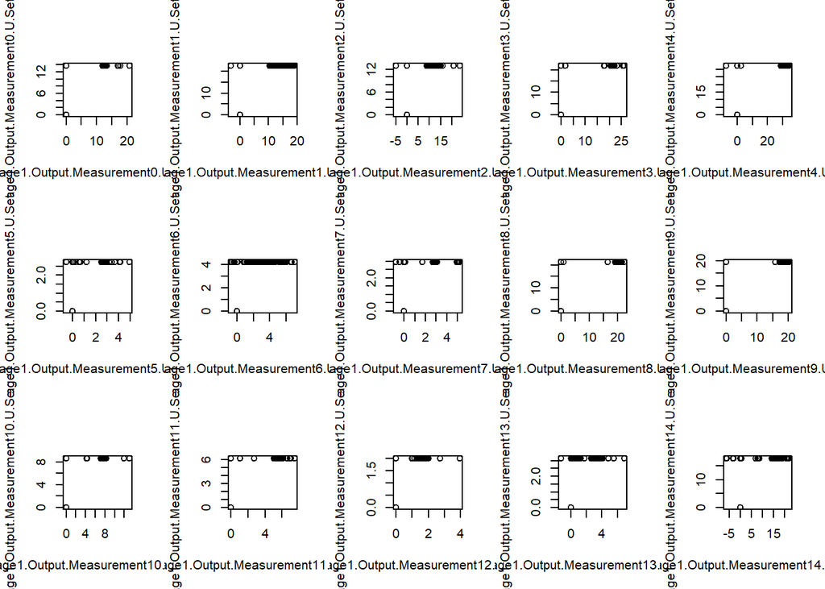

```r
# setpoint 관련 변수를 면밀히 조사
setidx <- grep('Setpoint', colnames(dat))

par(mfrow=c(3,5))
for (idx in setidx){
  plot(dat[,idx-1], dat[,idx], xlab=colnames(dat)[idx-1], ylab=colnames(dat)[idx])
}
```

```r
apply(dat[,setidx], 2, table)
```

```
## $Stage1.Output.Measurement0.U.Setpoint
##
##     0 13.75
##    56 14032
##
## $Stage1.Output.Measurement1.U.Setpoint
##
##     0 22.74
##    56 14032
##
## $Stage1.Output.Measurement2.U.Setpoint
##
##     0 13.02
##    56 14032
##
## $Stage1.Output.Measurement3.U.Setpoint
##
##     0 21.88
##    56 14032
##
## $Stage1.Output.Measurement4.U.Setpoint
##
##     0 32.55
##    56 14032
##
## $Stage1.Output.Measurement5.U.Setpoint
##
##     0  2.74
##    56 14032
##
## $Stage1.Output.Measurement6.U.Setpoint
##
##     0  4.25
##    56 14032
##
## $Stage1.Output.Measurement7.U.Setpoint
##
##     0  2.97
##    56 14032
##
```

[output cut: 94 more lines]

```
##
## $Stage2.Output.Measurement12.U.Setpoint
##
##  1.85
## 14088
##
## $Stage2.Output.Measurement13.U.Setpoint
##
##  2.89
## 14088
##
## $Stage2.Output.Measurement14.U.Setpoint
##
## 11.71
## 14088
```

```r
dat_set0 <- dat[dat[,setidx[1]]==0, ]
apply(dat_set0[,setidx], 2, table) # 0 제외 시 단일값 확인
```

```
##  Stage1.Output.Measurement0.U.Setpoint  Stage1.Output.Measurement1.U.Setpoint
##                                     56                                     56
##  Stage1.Output.Measurement2.U.Setpoint  Stage1.Output.Measurement3.U.Setpoint
##                                     56                                     56
##  Stage1.Output.Measurement4.U.Setpoint  Stage1.Output.Measurement5.U.Setpoint
##                                     56                                     56
##  Stage1.Output.Measurement6.U.Setpoint  Stage1.Output.Measurement7.U.Setpoint
##                                     56                                     56
##  Stage1.Output.Measurement8.U.Setpoint  Stage1.Output.Measurement9.U.Setpoint
##                                     56                                     56
## Stage1.Output.Measurement10.U.Setpoint Stage1.Output.Measurement11.U.Setpoint
##                                     56                                     56
## Stage1.Output.Measurement12.U.Setpoint Stage1.Output.Measurement13.U.Setpoint
##                                     56                                     56
## Stage1.Output.Measurement14.U.Setpoint  Stage2.Output.Measurement0.U.Setpoint
##                                     56                                     56
##  Stage2.Output.Measurement1.U.Setpoint  Stage2.Output.Measurement2.U.Setpoint
##                                     56                                     56
##  Stage2.Output.Measurement3.U.Setpoint  Stage2.Output.Measurement4.U.Setpoint
##                                     56                                     56
##  Stage2.Output.Measurement5.U.Setpoint  Stage2.Output.Measurement6.U.Setpoint
##                                     56                                     56
##  Stage2.Output.Measurement7.U.Setpoint  Stage2.Output.Measurement8.U.Setpoint
##                                     56                                     56
##  Stage2.Output.Measurement9.U.Setpoint Stage2.Output.Measurement10.U.Setpoint
##                                     56                                     56
## Stage2.Output.Measurement11.U.Setpoint Stage2.Output.Measurement12.U.Setpoint
##                                     56                                     56
## Stage2.Output.Measurement13.U.Setpoint Stage2.Output.Measurement14.U.Setpoint
##                                     56                                     56
```

```r
# 이상치 제거 (제거 대신 다른 방법을 쓸 수도 있음)
dat <- dat[dat[,setidx[1]]!=0, ]
apply(dat[,setidx],2,uniqval)
```

```
##  Stage1.Output.Measurement0.U.Setpoint  Stage1.Output.Measurement1.U.Setpoint
##                                      1                                      1
##  Stage1.Output.Measurement2.U.Setpoint  Stage1.Output.Measurement3.U.Setpoint
##                                      1                                      1
##  Stage1.Output.Measurement4.U.Setpoint  Stage1.Output.Measurement5.U.Setpoint
##                                      1                                      1
##  Stage1.Output.Measurement6.U.Setpoint  Stage1.Output.Measurement7.U.Setpoint
##                                      1                                      1
##  Stage1.Output.Measurement8.U.Setpoint  Stage1.Output.Measurement9.U.Setpoint
##                                      1                                      1
## Stage1.Output.Measurement10.U.Setpoint Stage1.Output.Measurement11.U.Setpoint
##                                      1                                      1
## Stage1.Output.Measurement12.U.Setpoint Stage1.Output.Measurement13.U.Setpoint
##                                      1                                      1
## Stage1.Output.Measurement14.U.Setpoint  Stage2.Output.Measurement0.U.Setpoint
##                                      1                                      1
##  Stage2.Output.Measurement1.U.Setpoint  Stage2.Output.Measurement2.U.Setpoint
##                                      1                                      1
##  Stage2.Output.Measurement3.U.Setpoint  Stage2.Output.Measurement4.U.Setpoint
##                                      1                                      1
##  Stage2.Output.Measurement5.U.Setpoint  Stage2.Output.Measurement6.U.Setpoint
##                                      1                                      1
##  Stage2.Output.Measurement7.U.Setpoint  Stage2.Output.Measurement8.U.Setpoint
##                                      1                                      1
##  Stage2.Output.Measurement9.U.Setpoint Stage2.Output.Measurement10.U.Setpoint
##                                      1                                      1
## Stage2.Output.Measurement11.U.Setpoint Stage2.Output.Measurement12.U.Setpoint
##                                      1                                      1
## Stage2.Output.Measurement13.U.Setpoint Stage2.Output.Measurement14.U.Setpoint
##                                      1                                      1
```

```r
# Setpoint 변수 삭제
dat <- dat[,-setidx]

# 다변량 회귀분석이 아닌 관계로 종속변수 평균화
depidx1 <- grep('Stage1.Output', colnames(dat))
depidx2 <- grep('Stage2.Output', colnames(dat))
dat$Stage1_Output <- apply(dat[,depidx1],1,mean)
dat$Stage2_Output <- apply(dat[,depidx2],1,mean)
dat <- dat[,-c(depidx1,depidx2)]

# 종속변수 기반 이상치 제거/보정
library(MASS)
outlier <- function(target){ # 방법 1) IQR
  iqr <- quantile(target, c(0.25, 0.75))
  (target < iqr[1] - 1.5 * diff(iqr))|(target > iqr[2] + 1.5 * diff(iqr))
}
outlier <- function(target){ # 방법 2) z-score
  z <- (target - mean(target)) / sd(target)
  abs(z) > 3
}
outlier <- function(target){ # 방법 3) Cook's distance
  temp <- dat[,-((ncol(dat)-1):ncol(dat))]
  temp <- cbind(temp, target)
  reg <- lm(target ~ ., data=temp)
  cd <- cooks.distance(reg)
  cd > 4 / (nrow(temp) - length(reg$coef))
}

### 1. 이상치 제거
dat <- dat[!(outlier(dat$Stage1_Output) & outlier(dat$Stage2_Output)),]

### 2. 이상치 보정 (평균치 또는 중앙값)
dat[!(outlier(dat$Stage1_Output) & outlier(dat$Stage2_Output)),] <- apply(dat[(outlier(dat$Stage1_Output) & outlier(dat$Stage2_Output)),],2,mean)
apply(dat[(outlier(dat$Stage1_Output) & outlier(dat$Stage2_Output)),],2,median)
```

```
##         AmbientConditions.AmbientHumidity.U.Actual
##                                          17.240000
##      AmbientConditions.AmbientTemperature.U.Actual
##                                          80.449921
##                     Machine1.RawMaterial.Property1
##                                          77.920501
##                     Machine1.RawMaterial.Property2
##                                         200.000000
##                     Machine1.RawMaterial.Property3
##                                         237.823977
##                     Machine1.RawMaterial.Property4
##                                         236.531915
##       Machine1.RawMaterialFeederParameter.U.Actual
##                                          72.165957
##                 Machine1.Zone1Temperature.C.Actual
##                                          72.100000
##                 Machine1.Zone2Temperature.C.Actual
##                                          80.002128
##                    Machine1.MotorAmperage.U.Actual
##                                          78.215675
##                         Machine1.MotorRPM.C.Actual
##                                          71.903423
##                 Machine1.MaterialPressure.U.Actual
##                                         431.600000
##              Machine1.MaterialTemperature.U.Actual
##                                          76.550000
##              Machine1.ExitZoneTemperature.C.Actual
##                                          72.442553
##                     Machine2.RawMaterial.Property1
##                                          17.141277
##                     Machine2.RawMaterial.Property2
##                                         289.917022
##                     Machine2.RawMaterial.Property3
##                                         367.465650
##                     Machine2.RawMaterial.Property4
##                                         257.000000
##       Machine2.RawMaterialFeederParameter.U.Actual
##                                         221.595000
##                 Machine2.Zone1Temperature.C.Actual
##                                          69.125000
```

[output cut: 59 more lines]

```
##                                         247.000000
##                     Machine5.Temperature3.C.Actual
##                                         263.900000
##                     Machine5.Temperature4.C.Actual
##                                         238.600000
##                     Machine5.Temperature5.C.Actual
##                                         213.739106
##                     Machine5.Temperature6.C.Actual
##                                          66.000000
##                  Machine5.ExitTemperature.U.Actual
##                                          13.909131
##                                      Stage1_Output
##                                          12.617660
##                                      Stage2_Output
##                                           8.853725
```

```r
# 변수명 변경
colnames(dat) <- gsub('.C[.]Actual','',colnames(dat))
colnames(dat) <- gsub('.U[.]Actual','',colnames(dat))
colnames(dat) <- gsub('[.]','_',colnames(dat))
colnames(dat) <- gsub('Machine','M',colnames(dat))
colnames(dat)
```

```
##  [1] "AmbientConditions_AmbientHumidity"
##  [2] "AmbientConditions_AmbientTemperature"
##  [3] "M1_RawMaterial_Property1"
##  [4] "M1_RawMaterial_Property2"
##  [5] "M1_RawMaterial_Property3"
##  [6] "M1_RawMaterial_Property4"
##  [7] "M1_RawMaterialFeederParameter"
##  [8] "M1_Zone1Temperature"
##  [9] "M1_Zone2Temperature"
## [10] "M1_MotorAmperage"
## [11] "M1_MotorRPM"
## [12] "M1_MaterialPressure"
## [13] "M1_MaterialTemperature"
## [14] "M1_ExitZoneTemperature"
## [15] "M2_RawMaterial_Property1"
```

[output cut: 42 more lines]

```r
# 트레인, 테스트셋 분할
library(caret)
```

[figure not shown]

[figure not shown]

```r
set.seed(0)
trainidx <- sample(1:nrow(dat), 0.7*nrow(dat))
trainset <- dat[trainidx,]
testset <- dat[-trainidx,]

# 표준화
depidx <- (ncol(trainset)-1):ncol(trainset)
scaling <- preProcess(trainset[, -depidx], method = c("center", "scale"))

traintarget <- trainset[,depidx]
trainsc <- predict(scaling, trainset[, -depidx])
trainsc <- cbind(trainsc, traintarget)

testtarget <- testset[,depidx]
testsc <- predict(scaling, testset[, -depidx])
testsc <- cbind(testsc, testtarget)

# 상관분석
library(corrplot)
corr <- cor(trainsc)
col <- colorRampPalette(c('white','blue'))
corrplot(abs(corr), method='color', col=col(200), type='upper',tl.cex = 0.5, tl.col='black')
# 공정별 데이터셋 정의
### Stage1의 경우 1차 공정 변수만 활용하기 때문에 별도로 변수 추출
extract <- function(data, type){
  if (type==1){ data[,c(1:41,56)] } else if (type==2) { data[,-56] }
}

trainsc1 <- extract(trainsc,1); trainsc2 <- extract(trainsc,2)
testsc1 <- extract(testsc,1); testsc2 <- extract(testsc,2)
```